# Анализ данных Московского метрополитена

## Описание проекта

Проект посвящён анализу пассажиропотока, географии и операционной эффективности Московского метрополитена и МЦД.  
Цель: выявить ключевые тренды, оценить эффективность линий и станций.  
Результаты предназначены для портфолио аналитика данных.

## Источники данных

Данные получены с портала data.mos.ru.  
Лицензия: [CC BY 4.0](https://creativecommons.org/licenses/by/4.0/deed.ru).  
В соответствии с [нормативной базой](https://data.gov.ru/normative_base).

### Датасеты:

- `data-624`: Станции метро и вестибюли
- `data-62743`: Пассажиропоток по станциям
- `data-62888`: Станции МЦД
- `data-62523`: Годовой пассажиропоток
- `data-62745`: Точность расписания
- `data-658`: Тарифы
- `data-62207`: Входы/выходы МЦД
- `data-62741`: Характеристики линий метро

## Инициализация и загрузка данных

### Используемые библиотеки:

- `pandas`, `numpy` — обработка и анализ данных
- `matplotlib`, `seaborn` — статическая визуализация
- `folium` — интерактивные карты
- `%matplotlib inline` — отображение графиков в ноутбуке

### Настройки:

- Стиль графиков: `seaborn-v0_8`, палитра `husl`
- Отображение таблиц: все столбцы, до 50 строк

### Загрузка и очистка данных:

- Источник: портал data.mos.ru
- Формат: CSV, разделитель `;`, кодировка UTF-8
- Пропущена первая строка (описание)
- Выполнена очистка:
  - `passenger_flow`: `Входы/Выходы` → `float`, пропуски → 0, добавлен `Общий пассажиропоток`
  - `stations`: координаты → `float`, удалены строки с `NaN`
  - `yearly_traffic`: `Пассажирский поток` → `float`, удалена колонка `Unnamed: 5`

**Загружено 8 датасетов.**

```
'Загружено 8 датасетов'
```

## Вкладка 1: Анализ пассажиропотока

### ТОП-10 станций по общему пассажиропотоку

Анализ станций выполнен с учётом привязки станции к линиям метрополитена.  
Пассажиропоток: сумма входов и выходов за весь период.  
Визуализация: горизонтальный барчарт + соотношение входов/выходов.

```
ТОП-10 станций по пассажиропотоку:
```

|  | Станция метрополитена | Линия | Входы пассажиров | Выходы пассажиров | Общий пассажиропоток |
| --- | --- | --- | --- | --- | --- |
| 93 | Комсомольская | Кольцевая линия | 141,337,263 | 117,333,473 | 258,670,736 |
| 301 | Щёлковская | Арбатско-Покровская линия | 111,357,026 | 105,771,484 | 217,128,510 |
| 43 | ВДНХ | Калужско-Рижская линия | 110,945,887 | 105,679,730 | 216,625,617 |
| 156 | Новогиреево | Калининская линия | 100,403,884 | 97,300,647 | 197,704,531 |
| 57 | Выхино | Таганско-Краснопресненская линия | 96,787,179 | 93,401,950 | 190,189,129 |
| 87 | Китай-город | Калужско-Рижская линия | 89,231,170 | 92,136,665 | 181,367,835 |
| 265 | Тёплый стан | Калужско-Рижская линия | 89,566,560 | 87,943,200 | 177,509,760 |
| 157 | Новокосино | Калининская линия | 87,178,188 | 84,412,236 | 171,590,424 |
| 109 | Кузьминки | Таганско-Краснопресненская линия | 85,572,206 | 85,316,055 | 170,888,261 |
| 229 | Славянский бульвар | Арбатско-Покровская линия | 84,892,046 | 82,859,130 | 167,751,176 |

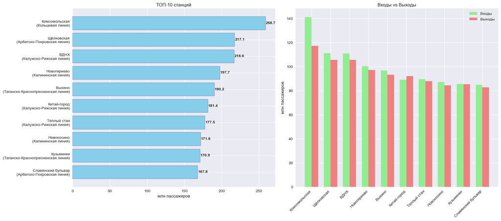

[output not shown]

## Вкладка 2: Географический анализ

### Интерактивная карта станций метро Москвы

**Без атрибуции и флагов** (чисто для портфолио)

- Только станции **на территории Москвы**
- Цвет маркера — **по линии**
- Popup: станция, линия, район, округ
- Tooltip: название и линия

```
Статистика:
• Станций в Москве: 1146
• Уникальных: 256
• Линий: 16
```

[interactive chart not shown]

### Особенности:

- CSS: скрыта атрибуция Leaflet
- `tiles='OpenStreetMap'` — русский язык

## Вкладка 3: Пересадки МЦД ↔ Метро

Анализ интеграции МЦД с метрополитеном:

- Извлечение пересадок из `geoData`
- Топ-станции и линии
- Визуализация: пай-чарт, барчарты, карта

```
Всего пересадок: 89
Уникальных станций метро: 52
Уникальных линий: 14
Уникальных станций МЦД: 47
```

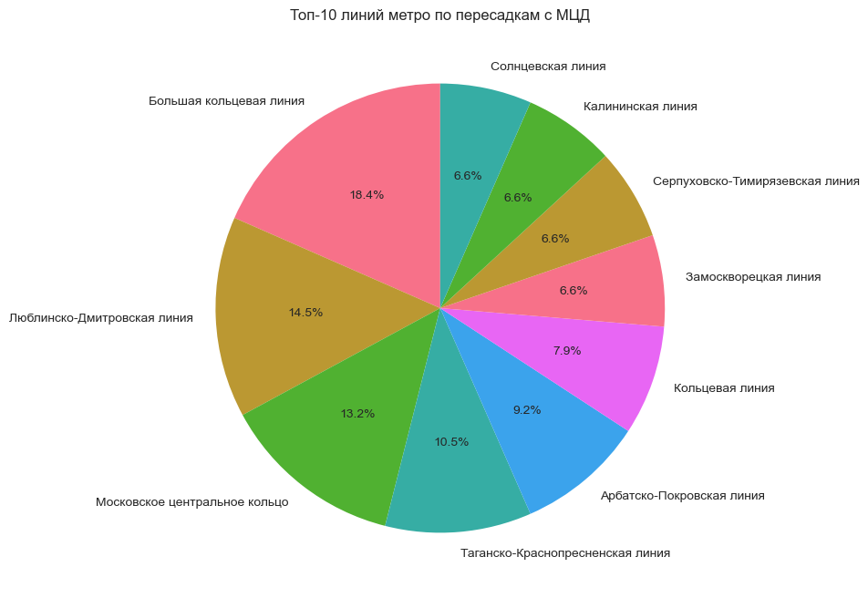

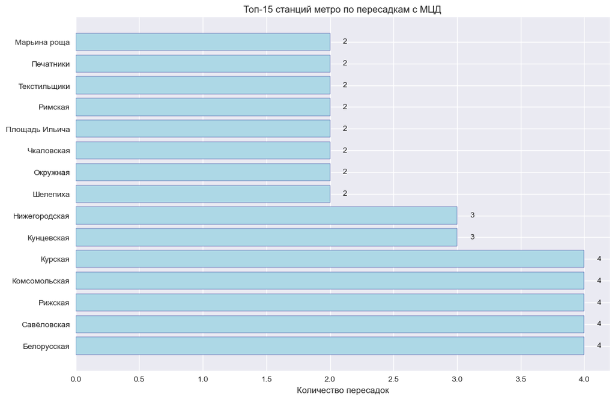

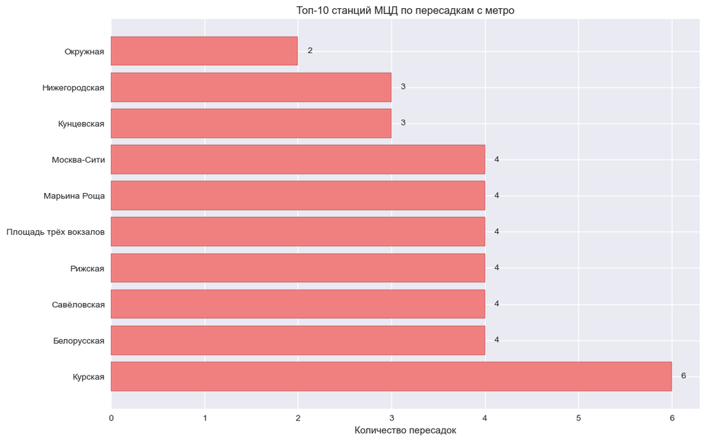

[interactive chart not shown]

```
Выводы:
• Всего пересадок: 89
• Лидеры по пересадкам: Белорусская, Савёловская, Рижская
• Самые загруженные линии: Большая кольцевая линия, Люблинско-Дмитровская линия
• Карта показывает плотную интеграцию МЦД с метро
```

## Вкладка 4: Пассажиропоток

Анализ годового и квартального пассажиропотока:

- Динамика по годам
- Влияние пандемии
- Сезонные паттерны
- Визуализация: линейные графики, барчарты

|  | Год | Пассажирский поток | Пассажирский поток (млрд) |
| --- | --- | --- | --- |
| 0 | 2019 | 4192986854 | 4.192987 |
| 1 | 2020 | 2657034372 | 2.657034 |
| 2 | 2021 | 3100722916 | 3.100723 |
| 3 | 2022 | 3334487252 | 3.334487 |
| 4 | 2023 | 3521245730 | 3.521246 |
| 5 | 2024 | 3714878380 | 3.714878 |

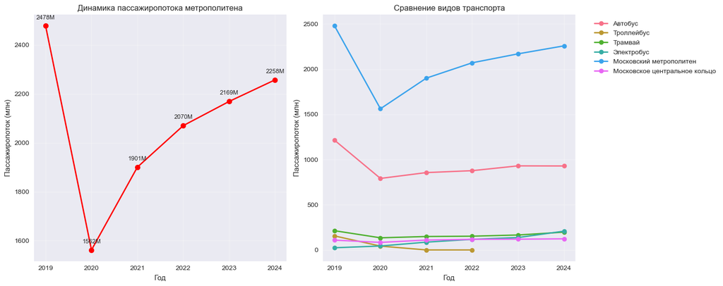

```
Структура пассажиропотока по видам транспорта в 2024 году:
• Московский метрополитен: 2.26 млрд (60.8%)
• Автобус: 0.93 млрд (25.0%)
• Трамвай: 0.20 млрд (5.3%)
• Электробус: 0.21 млрд (5.6%)

Анализ динамики пассажиропотока: пик 2019 и спад 2020
Ключевые показатели:
• 2019 год: 4.2 млрд пассажиров (максимум)
• 2020 год: 2.7 млрд пассажиров
• Снижение: 36.6%

Вероятные причины спада:
• Ограничения передвижения в связи с пандемией COVID-19
• Переход на удалённую работу и обучение
• Карантинные меры и локдауны
• Сокращение деловой активности и туризма

Динамика восстановления:
• 2021–2024: постепенное восстановление пассажиропотока
• Полное восстановление до уровня 2019 не достигнуто
• Изменение транспортных привычек населения

Оценка восстановления:
• Рост с 2020 по 2024: +39.8%
• До уровня 2019 не хватает: 11.4%
• Рост устойчив, но темпы ниже допандемийных
```

|  | Год | Квартал_число | Входы пассажиров | Выходы пассажиров | Общий пассажиропоток (млн) |
| --- | --- | --- | --- | --- | --- |
| 0 | 2021 | 1 | 452934258 | 453486462 | 906.4 |
| 1 | 2021 | 2 | 513138155 | 513385118 | 1026.5 |
| 2 | 2021 | 3 | 495109032 | 495291549 | 990.4 |
| 3 | 2021 | 4 | 549016205 | 544617362 | 1093.6 |
| 4 | 2022 | 1 | 503997473 | 504303169 | 1008.3 |
| 5 | 2022 | 2 | 558097044 | 558442438 | 1116.5 |
| 6 | 2022 | 3 | 543475571 | 543757171 | 1087.2 |
| 7 | 2022 | 4 | 578754407 | 579120385 | 1157.9 |
| 8 | 2023 | 1 | 528437875 | 528440389 | 1056.9 |
| 9 | 2023 | 2 | 577779722 | 577799126 | 1155.6 |

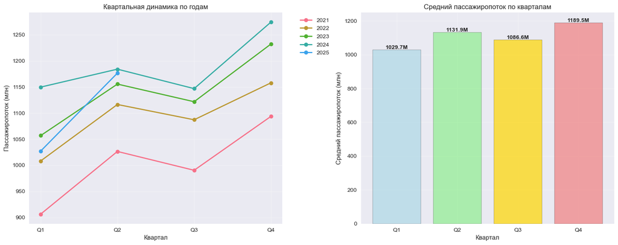

[output not shown]

## Вкладка 5: Эффективность линий метрополитена

Анализ загрузки и эффективности линий:

- Пассажиропоток по линиям
- Пассажиры на км и на станцию
- Визуализация: горизонтальные барчарты

```
Топ-5 линий по пассажиропотоку:
• Таганско-Краснопресненская линия: 2391.9 млн
• Калужско-Рижская линия: 2246.6 млн
• Замоскворецкая линия: 2123.6 млн
• Серпуховско-Тимирязевская линия: 2064.3 млн
• Арбатско-Покровская линия: 2017.9 млн
```

```
Самые эффективные линии (пассажиров на км):
• Кольцевая линия: 68.56 млн/км
• Калужско-Рижская линия: 59.39 млн/км
• Таганско-Краснопресненская линия: 56.90 млн/км
• Калининская линия: 54.57 млн/км
• Серпуховско-Тимирязевская линия: 49.97 млн/км

Самые загруженные линии (пассажиров на станцию):
• Калининская линия: 110.6 млн/станцию
• Кольцевая линия: 109.5 млн/станцию
• Таганско-Краснопресненская линия: 104.0 млн/станцию
• Калужско-Рижская линия: 93.6 млн/станцию
• Арбатско-Покровская линия: 91.7 млн/станцию
```

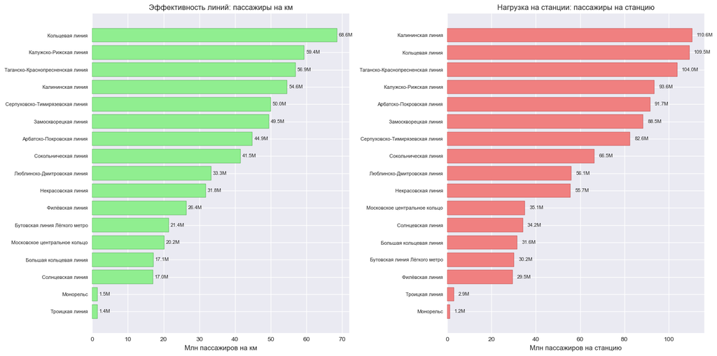

[output not shown]

## Вкладка 6: Операционная эффективность

Анализ точности соблюдения расписания:

- Средняя, минимальная и максимальная точность
- Динамика по годам
- Связь с пассажиропотоком
- Визуализация: точечная диаграмма

```
Годы в данных: [np.int64(2021), np.int64(2022), np.int64(2023), np.int64(2024), np.int64(2025)]
Средняя точность: 99.97%
Минимальная: 99.00%
Максимальная: 100.00%

Топ-5 линий по средней точности:
• Монорельс: 100.000%
• Филёвская линия: 99.993%
• Солнцевская линия: 99.993%
• Арбатско-Покровская линия: 99.992%
• Сокольническая линия: 99.990%
```

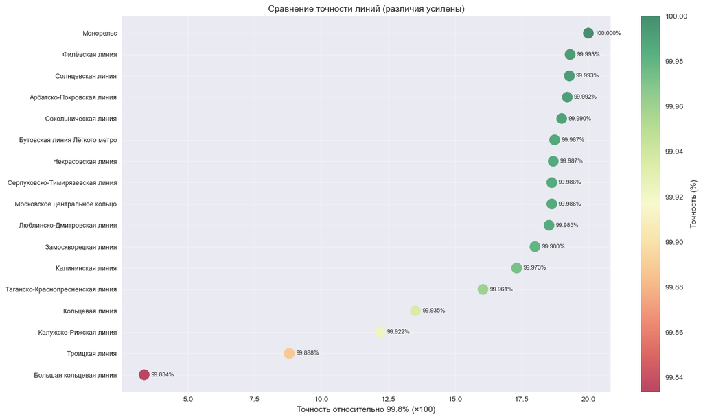

```
Динамика точности БКЛ:
• 2021: 99.985%
• 2022: 99.992%
• 2023: 99.983%
• 2024: 99.847%
• 2025: 99.203%

Динамика точности по годам (все линии):
```

| Год Линия | 2021 | 2022 | 2023 | 2024 | 2025 |
| --- | --- | --- | --- | --- | --- |
| Арбатско-Покровская линия | 99.990 | 99.998 | 99.992 | 99.992 | 99.987 |
| Большая кольцевая линия | 99.985 | 99.992 | 99.982 | 99.848 | 99.203 |
| Бутовская линия Лёгкого метро | 99.975 | 99.990 | 99.990 | 99.992 | 99.990 |
| Замоскворецкая линия | 99.990 | 99.990 | 99.992 | 99.977 | 99.940 |
| Калининская линия | 99.975 | 99.988 | 99.972 | 99.960 | 99.970 |
| Калужско-Рижская линия | 99.985 | 99.990 | 99.988 | 99.898 | 99.693 |
| Кольцевая линия | 99.938 | 99.977 | 99.975 | 99.878 | 99.900 |
| Люблинско-Дмитровская линия | 99.990 | 99.992 | 99.990 | 99.982 | 99.967 |
| Монорельс | 100.000 | 100.000 | 100.000 | 100.000 | 100.000 |
| Московское центральное кольцо | 99.982 | 99.982 | 99.988 | 99.992 | 99.987 |
| Некрасовская линия | 99.998 | 99.995 | 99.995 | 99.990 | 99.947 |
| Серпуховско-Тимирязевская линия | 99.988 | 99.990 | 99.992 | 99.985 | 99.973 |
| Сокольническая линия | 99.990 | 99.990 | 99.992 | 99.990 | 99.987 |
| Солнцевская линия | 99.990 | 99.994 | 99.992 | 99.992 | 99.997 |
| Таганско-Краснопресненская линия | 99.988 | 99.982 | 99.988 | 99.932 | 99.897 |
| Троицкая линия | NaN | NaN | NaN | 99.935 | 99.857 |
| Филёвская линия | 99.990 | 99.992 | 99.998 | 99.995 | 99.990 |

```
Связь точности и пассажиропотока:
```

|  | Линия | Точность_% | Пассажиропоток_млн |
| --- | --- | --- | --- |
| 0 | Арбатско-Покровская линия | 99.992 | 2017.931 |
| 1 | Большая кольцевая линия | 99.834 | 980.712 |
| 2 | Бутовская линия Лёгкого метро | 99.987 | 211.424 |
| 3 | Замоскворецкая линия | 99.980 | 2123.639 |
| 4 | Калининская линия | 99.973 | 885.051 |
| 5 | Калужско-Рижская линия | 99.922 | 2246.641 |
| 6 | Кольцевая линия | 99.935 | 1314.205 |
| 7 | Люблинско-Дмитровская линия | 99.985 | 1457.907 |
| 8 | Монорельс | 100.000 | NaN |
| 9 | Московское центральное кольцо | 99.986 | 1088.103 |
| 10 | Некрасовская линия | 99.987 | 445.535 |
| 11 | Серпуховско-Тимирязевская линия | 99.986 | 2064.298 |
| 12 | Сокольническая линия | 99.990 | 1795.669 |
| 13 | Солнцевская линия | 99.993 | 478.374 |
| 14 | Таганско-Краснопресненская линия | 99.961 | 2391.887 |
| 15 | Троицкая линия | 99.888 | 20.543 |
| 16 | Филёвская линия | 99.993 | 383.336 |

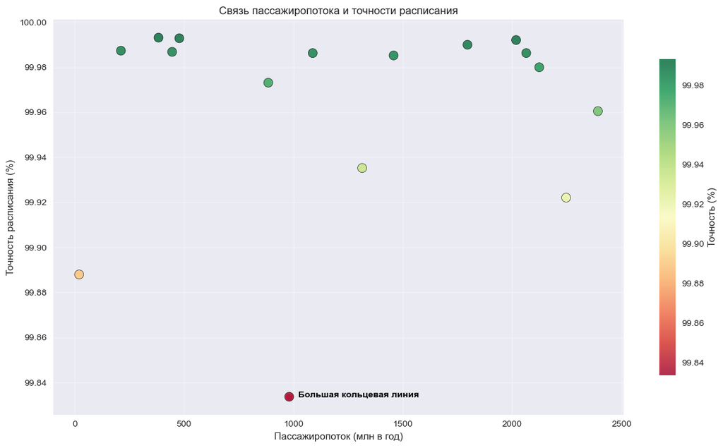

```
Выводы:
• Средняя точность по сети — выше 99.8%
• Новые линии (особенно БКЛ) демонстрируют снижение точности со временем
• Стабильные линии (Некрасовская, Солнцевская) — выше 99.9%
• Корреляция между пассажиропотоком и точностью не выявлена
• Операционная эффективность высока, но требует мониторинга на новых участках
```

## Вкладка 7: Анализ тарифов и выручки

Анализ:

- Основные тарифы (без льгот)
- Суточная стоимость
- Сценарии использования
- Оценка выручки метрополитена

```
ТАРИФЫ МОСКВА (Зона Центральная)
```

|  | Наименование тарифа | Стоимость проездного документа (рублей) | Срок действия проездного документа |
| --- | --- | --- | --- |
| 1 | «Единый» на 1 сутки | 365 | 1 сутки с момента первого прохода, начало использования - не позднее 10 суток с момента продажи |
| 2 | «Единый» на 3 суток | 700 | 3 суток с момента первого прохода, начало использования - не позднее 10 суток с момента продажи |
| 3 | «Единый» на 30 дней | 3070 | 30 дней с момент первого прохода, но не более 40 дней со дня продажи |
| 5 | «Единый» на 90 дней | 7430 | 90 дней с момент первого прохода, но не более 100 дней со дня продажи |
| 7 | «Единый» на 365 дней | 22000 | 365 дней с момент первого прохода, но не более 375 дней со дня продажи |
| 9 | «Кошелек» - «90 минут» | 94 | с момента изготовления на срок действия носителя |
| 11 | «Кошелек» | 63 | с момента изготовления на срок действия носителя |
| 14 | Оплата картой | 70 | день продажи |
| 15 | Оплата улыбкой | 59 | день продажи |

```
ТАРИФЫ ПРИГОРОД (Зона Пригород)
```

|  | Наименование тарифа | Стоимость проездного документа (рублей) | Срок действия проездного документа |
| --- | --- | --- | --- |
| 4 | «Единый» на 30 дней | 3750 | 30 дней с момент первого прохода, но не более 40 дней со дня продажи |
| 6 | «Единый» на 90 дней | 9600 | 90 дней с момент первого прохода, но не более 100 дней со дня продажи |
| 8 | «Единый» на 365 дней | 28000 | 365 дней с момент первого прохода, но не более 375 дней со дня продажи |
| 10 | «Кошелек» | 84 | с момента изготовления на срок действия носителя |
| 12 | Оплата картой | 91 | день продажи |
| 13 | Оплата улыбкой | 78 | - |

```
Визуализация суточной стоимости тарифов:
```

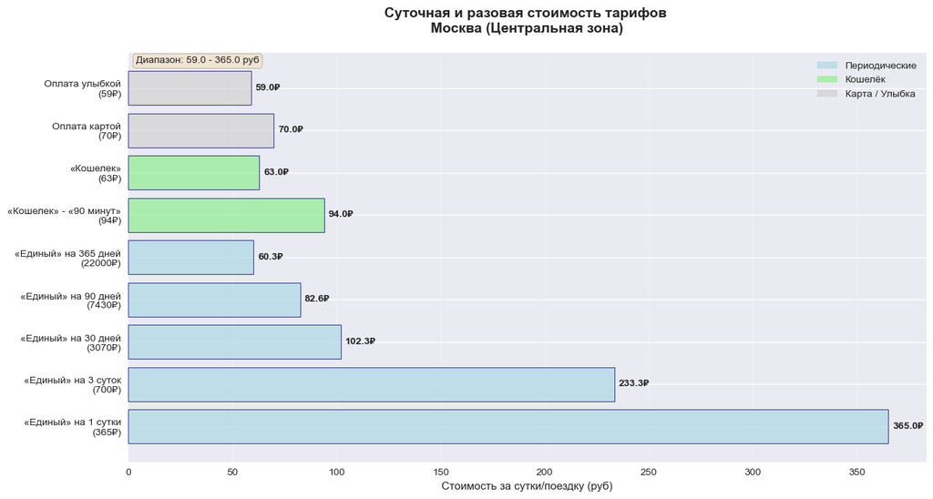

```
Статистика тарифов:
• Всего тарифов (не включая льготных): 9
• Самый дешёвый: 59.0 руб - Оплата улыбкой
• Самый дорогой: 365.0 руб - «Единый» на 1 сутки
```

```
Сценарий 'Только работа' (40 поездок/месяц):
• 30-дневный тариф: 3070₽
• Разовые поездки: 2520₽
• Переплата при тарифе: 550₽ в месяц

Сценарий 'Каждый день' (60 поездок/месяц):
• 30-дневный тариф: 3070₽
• Разовые поездки: 3780₽
• Экономия: 710₽ в месяц

Порог окупаемости 30-дневного тарифа:~ 49 поездок/месяц

Анализ выручки Метро:
• Пассажиропоток 2024: 3.7 млрд
• Средняя стоимость поездки: 82.7₽
• Оценочная выручка: 307.0 млрд рублей

Выводы:
• 'Только работа': выгоднее разовые поездки (экономия -550₽)
• 'Каждый день': выгоднее 30-дневный тариф (экономия 710₽)
• 30-дневный тариф выгоден при ≥ 49 поездок/месяц
• При редких поездках — выгоднее Оплата улыбкой (59.0₽)
• Тарифы универсальны: работают в метро + МЦД
• Тарифная политика сбалансирована по сценариям
```

## Вкладка 8: Детализация МЦД

Анализ инфраструктуры МЦД:

- Распределение по территории и округам
- Парсинг станций (диаметр, маршрут)
- Карта станций
- Сравнение с метрополитеном

```
Распределение по территории Москвы:
```

| На территории Москвы | Количество |
| --- | --- |
| да | 244 |
| нет | 153 |

```
Административные округа (Москва):
```

| Административный округ | Количество входов |
| --- | --- |
| Юго-Восточный административный округ | 45 |
| Северо-Восточный административный округ | 35 |
| Западный административный округ | 34 |
| Северный административный округ | 33 |
| Центральный административный округ | 21 |
| Новомосковский административный округ | 19 |
| Восточный административный округ | 16 |
| Южный административный округ | 15 |
| Северо-Западный административный округ | 11 |
| Зеленоградский административный округ | 9 |

```
Статистика:
• Всего входов/выходов: 397
• В Москве: 244 (61.5%)
• За пределами Москвы: 153
```

```
Распределение по диаметрам:
```

| Диаметр | Уникальные станции | Входов/выходов |
| --- | --- | --- |
| МЦД-1 | 25 | 87 |
| МЦД-2 | 35 | 108 |
| МЦД-3 | 39 | 129 |
| МЦД-4 | 36 | 73 |

```
Топ-10 районов Москвы по входам МЦД:
```

| Район | Количество входов |
| --- | --- |
| район Внуково | 14 |
| Нижегородский район | 13 |
| Можайский район | 10 |
| район Печатники | 9 |
| район Отрадное | 8 |
| Бутырский район | 7 |
| район Солнцево | 7 |
| Тимирязевский район | 7 |
| район Царицыно | 7 |
| район Лианозово | 7 |

```
Географический охват:
• Уникальных станций МЦД: 132
• Среднее входов на станцию: 3.0
```

[interactive chart not shown]

[output not shown]

```
Выводы:
• МЦД-3 — лидер (39 станций, 129 входов)
• 38.5% входов — за пределами Москвы
• Среднее ~ 3 входа на станцию
• МЦД дополняет метро, расширяя сеть в пригороды
• 89 пересадок — высокая интеграция
```

[output not shown]